# Act03

2026-06-14

A1: Read in the CSV file as a dataframe. Make sure to clean the data prior to performing the tasks below.

```r
  df <- read.csv("herpetozoa-033-095-s001.csv")
  good <- complete.cases(df)
  cdf <- df[good, ]
```

A2: Show the data structure.

```r
  class(cdf)
```

```
## [1] "data.frame"
```

```r
  str(cdf)
```

```
## 'data.frame':    49 obs. of  33 variables:
##  $ Sites   : chr  "ASG_ET1#" "ASG_ET4#" "ESG_ET5#" "CVT_ET6" ...
##  $ Long    : num  118 118 118 118 118 ...
##  $ Lat     : num  9.37 9.37 9.37 9.37 9.37 ...
##  $ Htypes  : chr  "ASG" "ASG" "ESG" "CVT" ...
##  $ Elev    : int  257 215 188 105 662 754 814 1020 474 425 ...
##  $ SPPTotal: int  0 0 0 0 1 1 1 1 1 1 ...
##  $ Babu    : int  0 0 0 0 0 0 0 0 0 0 ...
##  $ Inph    : int  0 0 0 0 0 0 0 0 0 0 ...
##  $ Liac    : int  0 0 0 0 0 0 0 0 0 0 ...
##  $ Lipa    : int  0 0 0 0 0 0 0 0 0 0 ...
##  $ Ocla    : int  0 0 0 0 0 0 0 0 0 0 ...
##  $ Leta    : int  0 0 0 0 0 0 0 0 0 0 ...
##  $ Meli    : int  0 0 0 0 0 0 0 0 0 0 ...
##  $ Chfu    : int  0 0 0 0 0 0 0 0 0 0 ...
```

[output cut: 19 more lines]

A3: Subset the elevation data and provide the mean, standard deviation, and range.

```r
  elev <- cdf[, 5]
  mean(elev)
```

```
## [1] 379.3878
```

```r
  sd(elev)
```

```
## [1] 240.5951
```

```r
  range(elev)
```

```
## [1]   60 1020
```

A4: Subset the species data (columns G to AG) and count the total number of observations per species. Show two methods, using a typical loop and a compact loop. Which species has the most and the fewest observations?

```r
  species <- cdf[, 7:33]
  loop <- 0
  for (i in seq_len(ncol(species))){
    loop[i] <- (sum(species[i]))
  }
  table <- matrix(loop, nrow = 27, ncol = 1)
  dimnames(table) <- list(names(species), "Observation sums")
  table
```

```
##      Observation sums
## Babu                1
## Inph                4
## Liac               28
## Lipa                2
## Ocla                5
## Leta               39
## Meli               17
## Chfu                7
## Pumo               51
## Sasa                8
## Stnu               35
## Phev                2
## Phlo              377
## Pole                2
## Poma                5
## Brsp                6
## Cyre                7
## Geat                1
## Gege                5
## Gemo                7
## Hety                1
## Eumu                2
## Bosc                1
## Dema                2
## Drru                1
## Apbo                1
## Trsu                2
```

```r
  cloop <- sapply(species, sum)
  cloop
```

```
## Babu Inph Liac Lipa Ocla Leta Meli Chfu Pumo Sasa Stnu Phev Phlo Pole Poma Brsp
##    1    4   28    2    5   39   17    7   51    8   35    2  377    2    5    6
## Cyre Geat Gege Gemo Hety Eumu Bosc Dema Drru Apbo Trsu
##    7    1    5    7    1    2    1    2    1    1    2
```

```r
  max(cloop)
```

```
## [1] 377
```

```r
  min(cloop)
```

```
## [1] 1
```

```r
  which(cloop == max(cloop))
```

```
## Phlo
##   13
```

```r
  which(cloop == min(cloop))
```

```
## Babu Geat Hety Bosc Drru Apbo
##    1   18   21   23   25   26
```

A5: Combine the columns of species with the most and fewest observations with habitat types (Htypes). Determine the mean count of these species in each habitat type. Which habitat type has the most species counts?

```r
  df03 <- cdf[c("Htypes", "Phlo", "Babu", "Geat", "Hety", "Bosc", "Drru", "Apbo")]
  ASG <- df03[df03$Htypes == "ASG", -1]
  CVT <- df03[df03$Htypes == "CVT", -1]
  ESG <- df03[df03$Htypes == "ESG", -1]
  OGF <- df03[df03$Htypes == "OGF", -1]
  ASG_mean <- sapply(ASG, mean)
  CVT_mean <- sapply(CVT, mean)
  ESG_mean <- sapply(ESG, mean)
  OGF_mean <- sapply(OGF, mean)
  table_mean <- cbind(ASG_mean, CVT_mean, ESG_mean, OGF_mean)
  table_mean
```

```
##        ASG_mean CVT_mean ESG_mean    OGF_mean
## Phlo 1.46666667        4        0 15.08695652
## Babu 0.00000000        0        0  0.04347826
## Geat 0.00000000        0        0  0.04347826
## Hety 0.06666667        0        0  0.00000000
## Bosc 0.06666667        0        0  0.00000000
## Drru 0.06666667        0        0  0.00000000
## Apbo 0.00000000        0        0  0.04347826
```

```r
  ASG_sum <- sapply(ASG, sum)
  CVT_sum <- sapply(CVT, sum)
  ESG_sum <- sapply(ESG, sum)
  OGF_sum <- sapply(OGF, sum)
  table_sum <- cbind(ASG_sum, CVT_sum, ESG_sum, OGF_sum)
  table_sum
```

```
##      ASG_sum CVT_sum ESG_sum OGF_sum
## Phlo      22       8       0     347
## Babu       0       0       0       1
## Geat       0       0       0       1
## Hety       1       0       0       0
## Bosc       1       0       0       0
## Drru       1       0       0       0
## Apbo       0       0       0       1
```

B1: From the original dataframe, combine the species total count column (SPPTotal) with the elevation and habitat type columns and create a scatter plot where elevation should be on the x-axis, while species total count is on the y-axis. Change the point colors based on habitat type. Are there habitat types with no species observations? What are these?

```r
  df032<- cdf[, 4:6]
  df032
```

```
##    Htypes Elev SPPTotal
## 1     ASG  257        0
## 2     ASG  215        0
## 3     ESG  188        0
## 4     CVT  105        0
## 5     OGF  662        1
## 6     OGF  754        1
## 7     OGF  814        1
## 8     OGF 1020        1
## 9     OGF  474        1
## 10    OGF  425        1
## 11    OGF  507        1
## 12    OGF  537        1
## 13    OGF  686        1
## 14    CVT  778        1
```

[output cut: 35 more lines]

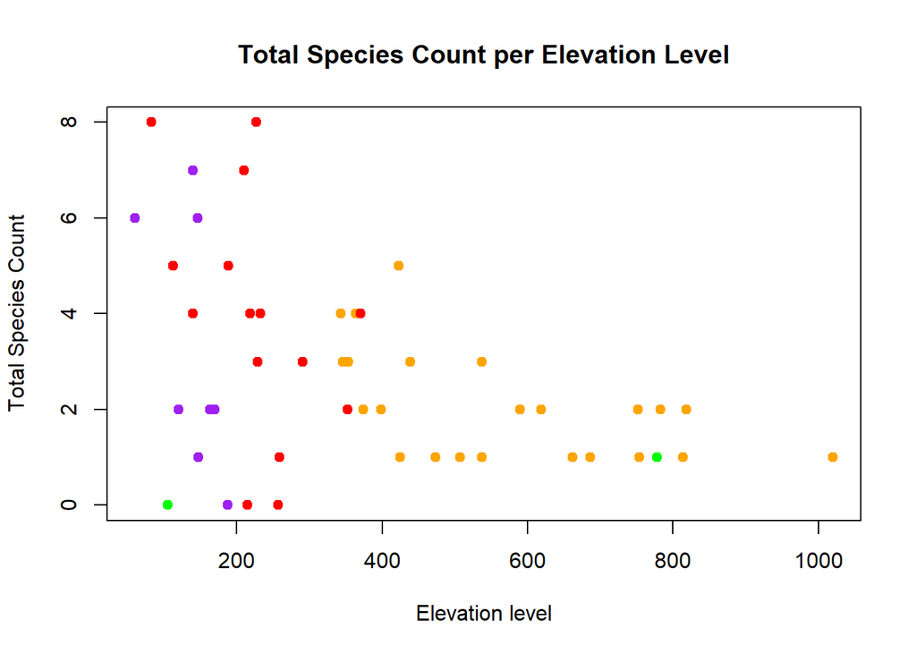

```r
  df032_col <- c(ASG = "red", CVT = "green", ESG = "purple", OGF = "orange")
  plot(
    df032$Elev,
    df032$SPPTotal,
    col = df032_col[df032$Htypes],
    pch = 19,
    main = "Total Species Count per Elevation Level",
    xlab = "Elevation level",
    ylab = "Total Species Count"
  )
```

```r
  df032[df032$SPPTotal == 0, ]
```

```
##   Htypes Elev SPPTotal
## 1    ASG  257        0
## 2    ASG  215        0
## 3    ESG  188        0
## 4    CVT  105        0
```

B2: From the combined data of species total counts, elevation, and habitat types, determine the total/sum number of species observed per habitat, and create a bar plot (use the bar plot help) where the x-axis shows the habitat types and the y-axis shows the total species.

```r
  ASG32 <- sum(df032[df032$Htypes == "ASG", -(1:2)])
  CVT32 <- sum(df032[df032$Htypes == "CVT", -(1:2)])
  ESG32 <- sum(df032[df032$Htypes == "ESG", -(1:2)])
  OGF32 <- sum(df032[df032$Htypes == "OGF", -(1:2)])
  bardf <- c(ASG32, CVT32, ESG32, OGF32)
  bardf
```

```
## [1] 58  1 28 48
```

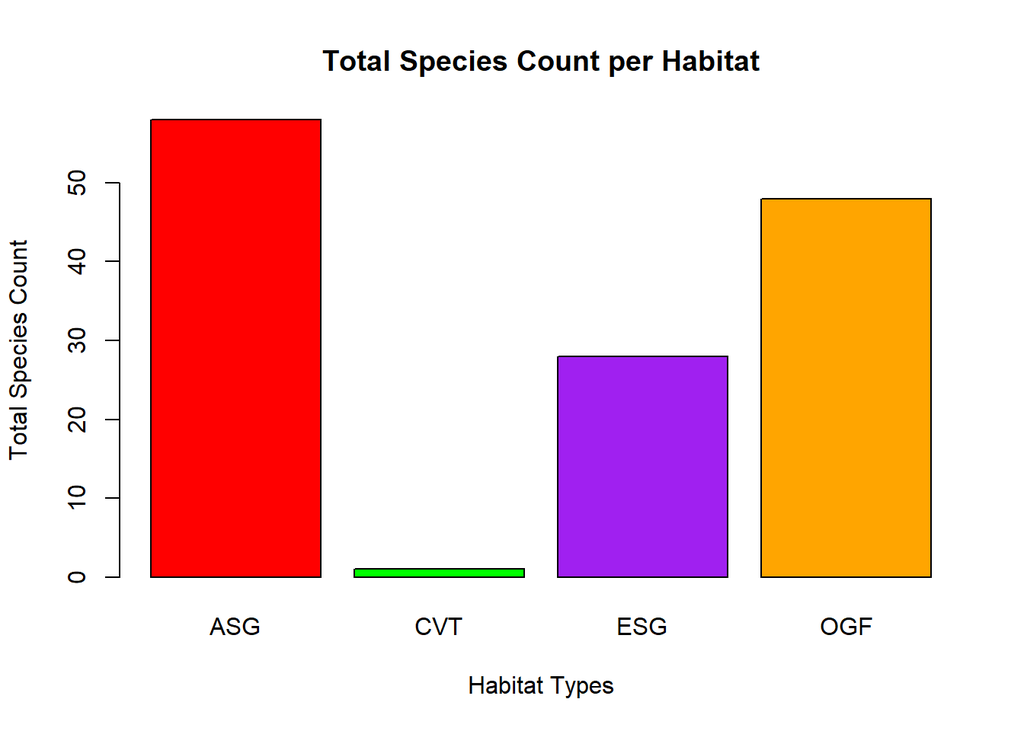

```r
  barplot(
    bardf,
    names.arg = c("ASG", "CVT", "ESG", "OGF"),
    main = "Total Species Count per Habitat",
    xlab = "Habitat Types",
    ylab = "Total Species Count",
    col = df032_col
  )
```

B3: Lastly, create a histogram of total species counts using the histogram function. Make sure all axes are properly labeled.

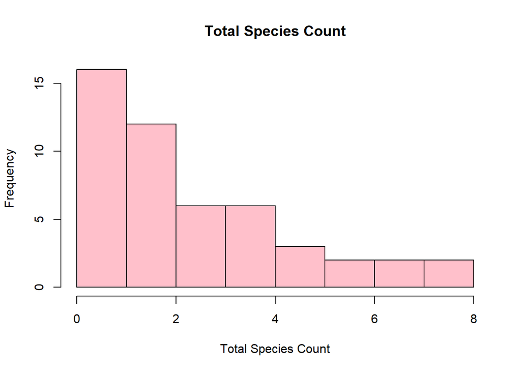

```r
  hist(
    df032$SPPTotal,
    main = "Total Species Count",
    xlab = "Total Species Count",
    ylab = "Frequency",
    col = "pink"
  )
```

C1: Based on the summary statistics and preliminary graphs you just created, how do you describe the relationship between total species observed and habitat types and elevation?

Based on the summary statistics, the elevation range is 60 to 1020 meters. The mean of the elevation is about 379 meters. Based on the scatter plot, lower elevation level has a higher species count. The bar plot shows that habitat ASG has the highest total species count, while CVT has the lowest.